# Genetic Algorithm for Optimization Problems

Inspired from biological evolution, the genetic algorithm can be used as a heuristic to find near optimial solutions for many large-scale optimization problems. The advantage of using the GA is its ease of implementation and generalization. Below is an implementation of the GA to find a near-optimal solution to the NP-Hard Traveling Salesman Problem.

## The Model

```python
import numpy as np
import matplotlib.pyplot as plt
```

We will use the well known Att48 dataset to set up the symmetric network. With 48 nodes, the number of possible solutions (tours) is $\frac{1}{2}(48-1)! = 1.29 \times 10^{59}$.

```python
def Att48Network():

    coords = np.loadtxt("https://people.sc.fsu.edu/~jburkardt/datasets/tsp/att48_xy.txt")
    N = len(coords)
    dists = {i: {j: np.sqrt((coords[i][0] - coords[j][0])**2 + (coords[i][1] - coords[j][1])**2)  for j in range(N) if j != i } for i in range(N)}

    return coords, dists, N
```

For the sake of demonstration to show the GA learning process, the initial generation of tours will be generated at random. In practice, generating better initial solutions is relatively easy (nearest neighbors,...) and reduces the learning needed for GA.

```python
def InitialRandomTours(P, N):

    tours = np.array([np.random.choice(N, N, replace=False) for i in range(P)])

    return tours
```

The below function will calculate the total distance for a given tour. This is our fitness function in which we aim to minimize.

```python
def CalcTotalDistance(tours, dists):

    tour_dists = []
    for t in tours:
        total = 0
        for i in range(len(t)-1):
            a = min(t[i], t[i+1])
            b = max(t[i], t[i+1])
            total += dists[a][b]
        a = min(t[i+1], t[0])
        b = max(t[i+1], t[0])
        total += dists[a][b]
        tour_dists.append(total)
    tour_dists = np.array(tour_dists)

    return tour_dists
```

After having a set of tours (a generation) and their distance (fitness), we need to define a way to pick solutions (parents) that have better paths (genes) than the general population to pass onto the next generation. The below function will use tournament selection to pick the parents from the current generation. After selecting $T$ tours at random, the tour with the best fitness will be choosen as a parent. The process continues until we have $G$ parents. Other methods of picking parents exist, such as probaility weighted selection based on fitness.

```python
def PickParents(tours, tour_dists, P, G, T):

    parents_idx = []
    field = np.arange(P)
    for i in range(G):
        tournament = np.random.choice(field, T, replace=False)
        winner = tournament[np.where(tour_dists[tournament] == tour_dists[tournament].min())][0]
        parents_idx.append(winner)
        field = np.delete(field, np.argwhere(field==winner))

    parents = tours[parents_idx]

    return parents
```

After selection of the parents, we need to generate the next set of solutions (children) that inherit paths from their parents. This function will select a parent at random and passes a random portion of its tour to the child. The path from the second parent selected at random will complete the child's tour. This is repeated until we have another full generation.

```python
def CreateNextGeneration(parents, P, N, G):

    children = []
    for i in range(P):
        cross = np.random.choice(N, 2, replace=False)
        mates = np.random.choice(G, 2, replace=False)
        child = list(parents[mates[0]][min(cross):max(cross)])
        for j in np.roll(parents[mates[1]], child[-1]):
            if j not in child:
                child.append(j)
        children.append(child)

    children = np.array(children)

    return children
```

```python
def MutatePopulation(tours, N, p = 0.05):

    s = np.random.random_sample(len(tours))
    ind = np.argwhere(s <= p).reshape(-1)
    for i in ind:
        switch = np.random.choice(N, 2, replace=False)
        a = tours[i, switch[0]]
        b = tours[i, switch[1]]
        tours[i, switch[1]] = b
        tours[i, switch[0]] = a

    return tours
```

Now we are ready to train the model. Since it is not known what the best set of parameters are (population size, tournamanet size, parent size, mutation rate), the below script will loop through different combinations of parameters to generate 750 generations. The learning for each generation will be plotted and the best solution will be stored. The dashed black line shows the optimal tour distance.

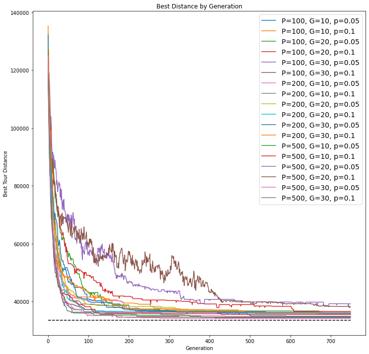

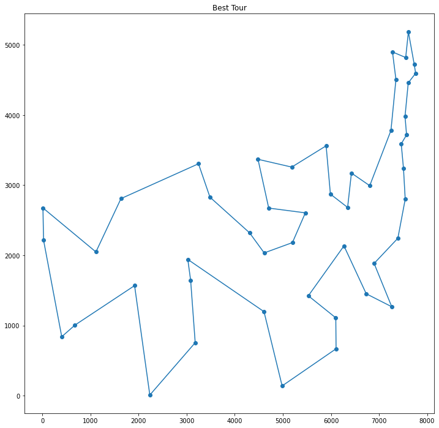

```python
coords, dists, N = Att48Network()

sol_dist = np.inf
Gens = 750
T = 50

plt.rcParams['figure.figsize'] = [12, 12]
plt.figure()
for P in [100, 200, 500]:
    for G in [10, 20, 30]:
        for p in [0.05, 0.1]:
            best_tours = []
            tours = InitialRandomTours(P, N)
            for i in range(Gens):
                #print(i)
                tour_dists = CalcTotalDistance(tours, dists)
                best_dist = min(tour_dists)
                best_tours.append(best_dist)
                if best_dist < sol_dist:
                    sol_dist = best_dist
                    sol_tour = tours[np.argwhere(tour_dists == sol_dist)][0]
                    best_params = [P, G, p, T]
                parents = PickParents(tours, tour_dists, P, G, T)
                children = CreateNextGeneration(parents, P, N, G)
                children = MutatePopulation(children, N, p = p)
                tours = children
            plt.plot(best_tours, label = "P=" + str(P) + ", G=" + str(G) + ", p=" + str(p))
plt.plot([33_532] * Gens, linestyle = "--", color = "black")
plt.legend(loc = 1, prop={'size': 14})
plt.xlabel('Generation')
plt.ylabel('Best Tour Distance')
plt.title('Best Distance by Generation')
plt.show()

solution_coords = coords[sol_tour.reshape(N)].reshape(N, 2)
solution_coords = np.vstack([solution_coords, solution_coords[0, :]])

plt.figure()
plt.scatter(coords[:, 0], coords[:, 1])
plt.plot(solution_coords[:, 0], solution_coords[:, 1])
plt.title('Best Tour')
plt.show()
```

```python
print(round(sol_dist))
print(str(round((sol_dist - 33_523) / 33_523, 4) * 100) + "%")
print(best_params)
```

```
34202
2.03%
[500, 30, 0.05, 50]
```

In the end, the algorithm finds a solution that is within about 2% of the known optimal solution.